# R Notebook

Load the libraries

```r
library(magrittr)
library(reshape2)
library(plyr)
library(dplyr)
library(tidyr)
```

```r
library(ggplot2)
library(tm)
library(rpart)
library(caret)
library(mlr)
library(parallelMap)
library(doParallel)
library(missForest)
library(scales)
library(ggthemes)
library(GGally)
library(ltm)
library(rpart.plot)
library(knitr)
```

# Introduction

According to the anti malware company Malwarebytes, “Spam is any kind of unwanted, unsolicited digital communication, often an email, that gets sent out in bulk. Spam is a huge waste of time and resources.” At its most benign, spam is the digital equivalent of junk mail costing receipents nothing more than time and aggravation. However, spam emails can expose individuals and companies to a litany of attacks including phishing, ransomware, and most recently cryptojacking. These cyber attacks can result in significant costs to companies in the form of lost time, revenue, resources, and intelectual property. Without a good spam filter even the most sophisticated layered cyber defense system is vulnerable to a cyber attack that originates from malicious email carelessly opened by a trusting employee. For this reason spam filters are just as important to cyber security as firewalls .

The simplest forms of filters are list-based filters which as the name implies, take lists of words from a combination of black lists, grey lists, and white lists and compares the words in an email to its list, to determine if the email should be blocked, flagged, or allowed. These filters require continous list updates and result in both high false positve and false negative designations. A more effective filter is the heuristic filter that makes use of statistical methods and machine learning algorithms to determine the probablity that an individual email is spam. In this study we will create a decision tree based spam filter and compare it to a naive bayes based filter to determine the accuracy and precision of each.

# Data

```r
#setwd("/Users/danielclark/Desktop/SMU/Quantifying_the_World/Unit 5/Week_5_Materials")
setwd("C:/Users/Akuma2099/MachineLearning/QTW_Project_3")
load("data.Rda")
load("resampling_binary")
load("spam.tuned.clf")

ls()
```

```
## [1] "emailDFrp"       "spam.resamp.bin" "spam.tuned.clf"
```

The data consists of 9348 observations. Each observation represents one email message with up to 30 variables. The first variable, “isSpam” is a 2 level categorical variable that denotes whether the message was known to be spam. This will serve as the response variable for the study. The remaining variables consist of 16 categorical and 13 numeric variables that repesent characteristics of the email such such as “isRe” which denotes if an email contains the “RE” prefix in the subject line, “hour” which denotes the hour of the day in which the email was received, “bodyCharCt” which represents the number of characters in the body of the message, and “perCaps” which represents the percent of characters that where capitalized.

```
## 'data.frame':    9348 obs. of  30 variables:
##  $ isSpam       : Factor w/ 2 levels "F","T": 1 1 1 1 1 1 1 1 1 1 ...
##  $ isRe         : Factor w/ 2 levels "F","T": 2 1 1 1 2 2 1 2 1 2 ...
##  $ underscore   : Factor w/ 2 levels "F","T": 1 1 1 1 1 1 1 1 1 1 ...
##  $ priority     : Factor w/ 2 levels "F","T": 1 1 1 1 1 1 1 1 1 1 ...
##  $ isInReplyTo  : Factor w/ 2 levels "F","T": 2 1 1 1 1 2 1 1 1 2 ...
##  $ sortedRec    : Factor w/ 2 levels "F","T": 2 2 2 2 2 2 2 2 2 2 ...
##  $ subPunc      : Factor w/ 2 levels "F","T": 1 1 1 1 1 1 1 1 1 1 ...
##  $ multipartText: Factor w/ 2 levels "F","T": 1 1 1 1 1 1 1 1 1 1 ...
##  $ hasImages    : Factor w/ 2 levels "F","T": 1 1 1 1 1 1 1 1 1 1 ...
##  $ isPGPsigned  : Factor w/ 2 levels "F","T": 1 1 1 1 1 1 1 1 1 1 ...
##  $ subSpamWords : Factor w/ 2 levels "F","T": 1 1 1 1 1 1 1 1 1 1 ...
##  $ noHost       : Factor w/ 2 levels "F","T": 1 1 1 1 1 1 1 1 1 1 ...
##  $ numEnd       : Factor w/ 2 levels "F","T": 1 1 1 1 1 1 1 1 1 1 ...
##  $ isYelling    : Factor w/ 2 levels "F","T": 1 1 1 1 1 1 1 1 1 1 ...
```

[output cut: 16 more lines]

For better interpretation we renamed and releveled the resonse varaible from “T” and “F” to “Spam” and “valid”.

```r
emailDFrp$isSpam <- emailDFrp$isSpam %>%
                      revalue(c("T"="Spam", "F"="Valid")) %>%
                        relevel("Spam")
```

- subSpamWords
- subQuesCt
- subExcCt
- SubBlanks
- numRec
- noHost
- isYelling

This indicates that up to 3.9% of our observations could have missing values.

```r
sapply(emailDFrp, function(x) sum(is.na(x)))
```

```
##        isSpam          isRe    underscore      priority   isInReplyTo
##             0             0             0             0             0
##     sortedRec       subPunc multipartText     hasImages   isPGPsigned
##             0             0             0             0             0
##  subSpamWords        noHost        numEnd     isYelling     isOrigMsg
##             7             1             0             7             0
##        isDear       isWrote      numLines    bodyCharCt      subExcCt
##             0             0             0             0            20
##     subQuesCt        numAtt        numRec       perCaps          hour
##            20             0           282             0             0
##       perHTML     subBlanks      forwards    avgWordLen        numDlr
##             0            20             0             0             0
```

Though dropping the missing values was an option, for this study we decided to impute the missing values based on random forest classification and regesssion using a parallel method.

```r
registerDoParallel(cores=4)

df <- missForest(emailDFrp,
                 maxiter=5,
                 ntree=200,
                 parallelize = c('forests'),
                 variablewise = TRUE)
```

```
##   missForest iteration 1 in progress...done!
##   missForest iteration 2 in progress...done!
##   missForest iteration 3 in progress...done!
```

```r
# establish imputed set
emailDFrp <- df$ximp
```

The imputed values were merged into the original dataset to create a complete dataset with no missing values.

```r
sum(is.na(emailDFrp))
```

```
## [1] 0
```

# Exploratory Data Analysis

After ensuring that no missing values existed in the data set we began our exploratory data analysis by examining the distribution of the response variable.

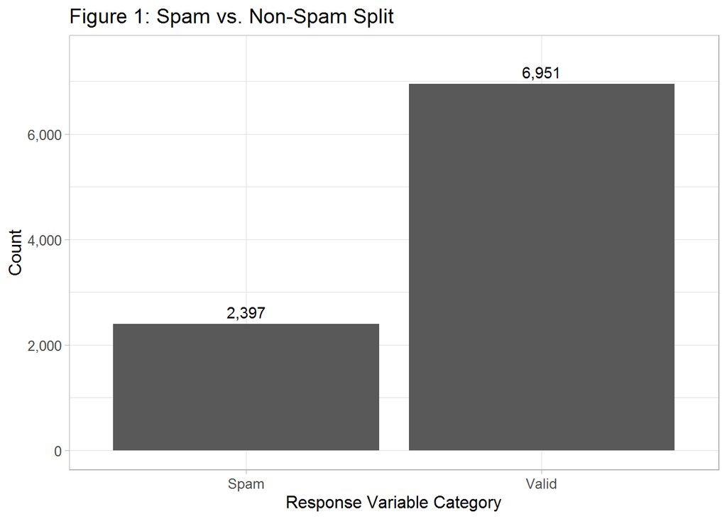

The chart above shows that we have an unbalanced dataset with nearly 2,400 spam emails compared to nearly 7,000 nonspam emails (valid) emails. This means that, roughly, 1 out of every 4 emails in our set are considered spam. This fact highlights the possible need to account for the imbalance in our future modeling, and ensure that we are tuning and training our models such that they are not being rewarded for leaning too much on assigning the valid class to new valid. That said, since the unbalance isn’t huge, we will not need to apply oversampling mehtods to address this issue.

A quick review of the numeric variables indicates that there is a great degree of variation both within and between the individual variables. This indicates that normalization or standardization might be necessary.

```
##     numLines         bodyCharCt        subExcCt         subQuesCt
##  Min.   :   2.00   Min.   :     6   Min.   : 0.0000   Min.   : 0.0000
##  1st Qu.:  19.00   1st Qu.:   587   1st Qu.: 0.0000   1st Qu.: 0.0000
##  Median :  32.00   Median :  1088   Median : 0.0000   Median : 0.0000
##  Mean   :  66.91   Mean   :  2844   Mean   : 0.1315   Mean   : 0.1377
##  3rd Qu.:  59.00   3rd Qu.:  2192   3rd Qu.: 0.0000   3rd Qu.: 0.0000
##  Max.   :6319.00   Max.   :188505   Max.   :42.0000   Max.   :12.0000
##      numAtt             numRec           perCaps             hour
##  Min.   : 0.00000   Min.   :  0.000   Min.   :  0.000   Min.   : 0.00
##  1st Qu.: 0.00000   1st Qu.:  1.000   1st Qu.:  4.255   1st Qu.: 8.00
##  Median : 0.00000   Median :  1.000   Median :  6.055   Median :13.00
##  Mean   : 0.06579   Mean   :  1.918   Mean   :  8.850   Mean   :12.21
##  3rd Qu.: 0.00000   3rd Qu.:  1.396   3rd Qu.:  9.059   3rd Qu.:18.00
##  Max.   :18.00000   Max.   :311.000   Max.   :100.000   Max.   :23.00
##     perHTML          subBlanks        forwards       avgWordLen
##  Min.   :  0.000   Min.   : 0.00   Min.   : 0.00   Min.   : 1.363
##  1st Qu.:  0.000   1st Qu.:10.53   1st Qu.: 0.00   1st Qu.: 4.208
##  Median :  0.000   Median :13.24   Median : 0.00   Median : 4.455
##  Mean   :  6.517   Mean   :13.87   Mean   :10.45   Mean   : 4.487
##  3rd Qu.:  0.000   3rd Qu.:15.69   3rd Qu.:15.38   3rd Qu.: 4.729
##  Max.   :100.000   Max.   :86.42   Max.   :99.06   Max.   :26.000
##      numDlr
##  Min.   :   0.000
##  1st Qu.:   0.000
##  Median :   0.000
##  Mean   :   1.782
##  3rd Qu.:   0.000
##  Max.   :1977.000
```

#### Explanatory Variable Relationships

With Regards to our imputed dataset, the correlation matrix shows that slight positive and negative correlations exist between our numeric predictors, with the only strong (.92) multicolinear relationship being between “bodyCharCt” and “numLines”.

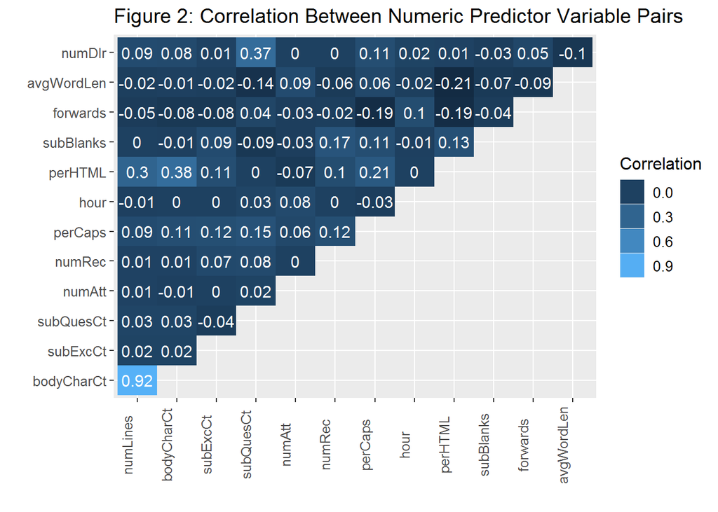

Looking at the data, we can see three addtional positive relationships can be pointed out.

- perHTML and numLines (.30)
- perHTML and bodyCahrCt (.38)
- numDir and subQuesCt (.37)

While not very high, the correlation of these predictors can potentially be overweighed in our modeling procedures, due to the fact that they might not be independent. For example, numLines and bodyCharct are both functions of the length of the email in question, so they are very similar metrics. However, if we use recursive partitioning in our modeling, the collinearity between these pairs of variables will be accounted for, by selecting the most important variable if similar variables are found.

Looking at the non-numerical values in our dataset, we can see that we have 16 boolean values that we can factor our model into as well. To do so, we will employ the Fisher’s exact p-test to show the resulting p-values for our dichotomous variables, which we will use as a numerical comparison similar to how we used correlation on our numerical variables.

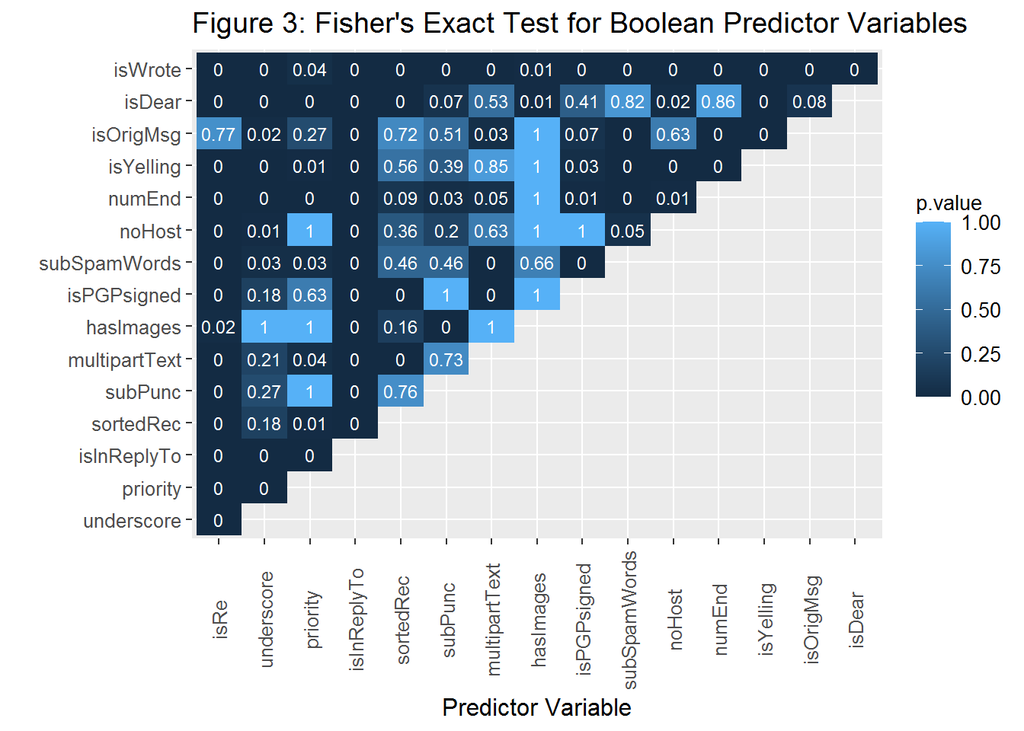

The lower p values indicate that we reject the null of a randomized assocation between dichotomous variables. Here we can see that there are some large non random dependencies for variables such as “isWrote” which indicate whether an email is electronically scribed. Since this is apparent in almost all instances, we can likely remove. HOwever, there are some instances for variables such as “priority” and “noHost” which may be interesting for classifying spam or not spam. This would make sense as the lack of host name and sender are variables written by the email sender.

We can also visually review the correlation between factors and continuous variables using a biserial correlation (as we have dichotomous factors for all of our non-continuous variables). Upon review, we can see some relationships emerge.

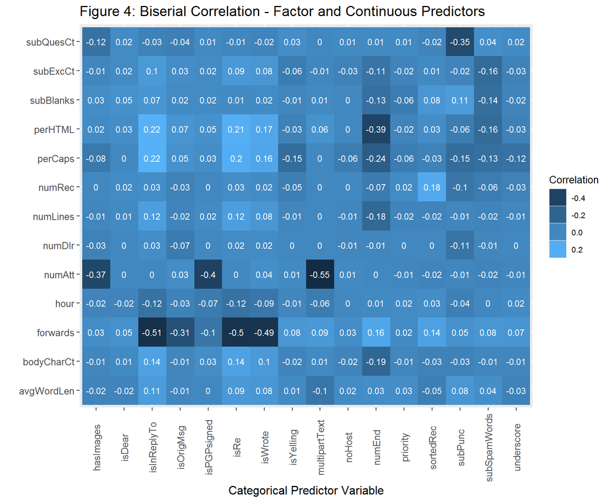

Reviewing the plot further, we can see that the number of attachments (numAtt) has a negative correlation with the boolean value of “multipartText”. Multipart text messages typically do not typically have attachments. In addition, we are seeing that the variable for number of forwards has a negative correlation to “isInReplyTo”, which suggests that the replies do not typically have a ton of forwards.

Overall, we will look into ways that continuous and categorical variables can be used to predict the response variable “isSpam”" while also pulling out the variable importances in the rpart package.

#### Response Variable Relationships

As we mentioned before, the majority of instances in our dataset are not considered spam. That said, we can visualize the relationships between spam and valid emails for the categorical and continuous predictor variables using different plotting techniques.

First, we will look further into “isRe”, “numEnd”, “subSpamWords” and “isWrote”. The variable “numEnd” indicates whether or not the ‘from’ email prefix ends with a number, such as ‘clark.daniel424@gmail.com.’

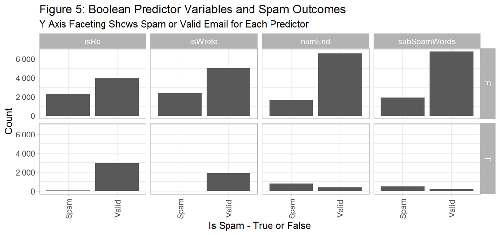

In the chart above, subSpamWords is a boolean that indicates when a known “spam word” is indicated in the subject of an email, such as “viagra” which would trigger a value for subSpamwords. The majority of our spam cases happen when our factors are set to false. Additionally, the mostly valid emails are related to instances when “isRe” and “isWrote” are set to true. This will prove to be usefull when seeing how a decision tree can be split between our categorical variables in the decision function to determine if an email is spam or not spam.

We will also look into the separation of classes for numeric variables by looking at the log values for our numeric placements in a box plots. We will review some of the interesting numerics in the figure below.

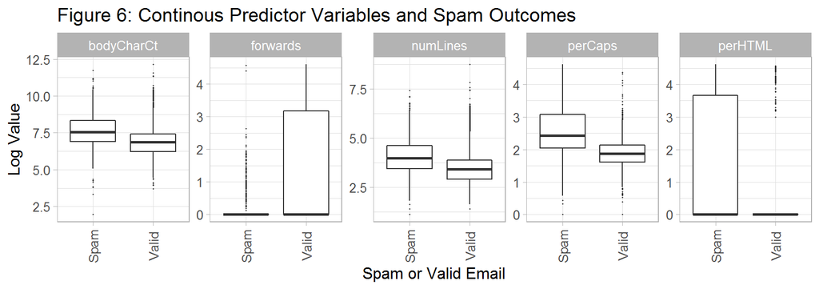

The “forwards” predictor variable, shows a great concentration of value distribution for the third quartile of messages that are labeled as valid. The “perCaps” predictor variable shows a larger predictor interval for spam than valid emails. We can also see that the median value for spam is higher than the valid messages. On “perHTML”, the mean and median value for valid emails is nearly zero while the range is much greater for the spam messages.

Examination of these predictor variables indicates that we may have some leads to uncovering a predictor and an important features related to detecting spam.

# Modeling

### Variable Selection and Model Comparison Setup

In hopes to avoid the complexity of variable selection algorithms to run an algorithm against our email data set, we will set up a fit of an rpart model using the training data an all 29 features and default model parameters. For the default parameters for rpart, we will use a minsplit of 20 along with a complexity parameter of 0.01 with a max depth of 30. The splitting criteria will use the default Gini Index.

for our setup, we will use an 80/20 split between the training and testing set. Since we have an imbalanced relationship between spam emails and valid emails, we can use a stratified sampling of the observations in our training and testing data sets to ensure we maintain the original balance. We have 9,348 total observations, so this would mean that our testing set will have roughly 1,800 observations.

As we will run a series of models in our experiment, we will maintain this distribution of training and testing data for each model to ensure that we are running a valid experiment. As our rpart is trained, it will provide a listing of variables that are playing the greatest role in deciding upon valid or spam email. The chart below provides the most important features using the rpart base model.

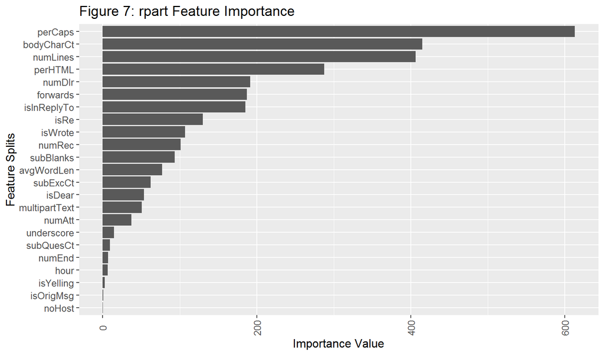

We will also look into the rpart control parameters and their ability to classify spam emails based on fitting a separate, optimized rpart model. To do this, we will look into 4 different parameters for tuning. Below, we outline the description of these.

- Complexity parameter (cp) - A scaled complexity penalty that ranges from 0 to 1. cp is compared against the error rate related to the previous split. Any split that doesn’t decrease the error rate is not considered.
- Minsplit - the minimum number of observations that need to exist in a node in order for the split to be attempted.
- Maxdepth - The maximum depth of any node of the final tree, with the root node counted at depth 0.
- Splitting criteria - or the gini or information. It utilizes the gini index to optimize split points and entropy and information gain.

We will use decision trees to ensure we are using these parameters in such a way that we don’t overfit.

#### Hyperparameter Optimization

We will be exploring a discrete list of the four parameters of interest to help ensure we are running the models as quickly and efficiently as possible. A grid search procedure will be used in conjuction with a ten-fold cross-validation.

We are going to be using our 4 panel procedure for evaluating classification performance and maximizing true positive classification where “spam” is the positive class. We will measure this using an ROC (AUC) curve and determining which model provides us the greatest area under the curve. A false positive would mean that a valid email will be marked as spam. A false negative would mean that a spam message ends up in the important inbox. The latter two would mean that we have a model error.

## Base Model Results

Our base model listed “perCaps” as our most important feature followed by “BodyCharCt”. Given this, we will look at an rpart model that uses only “perCaps”" and “BodyCharCt”.

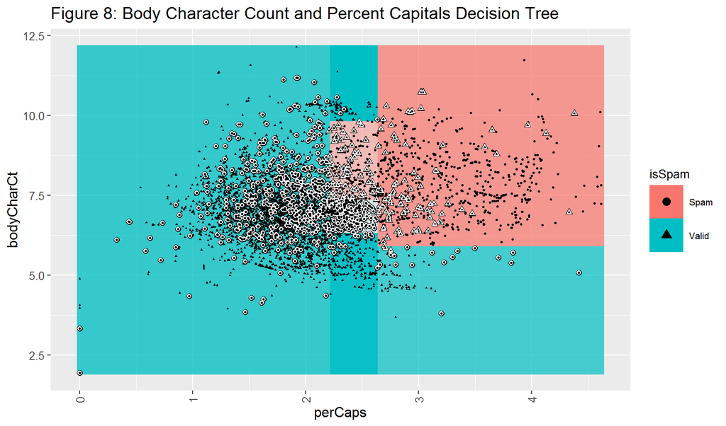

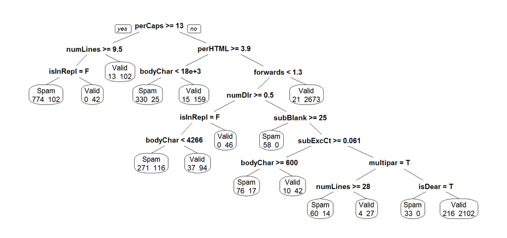

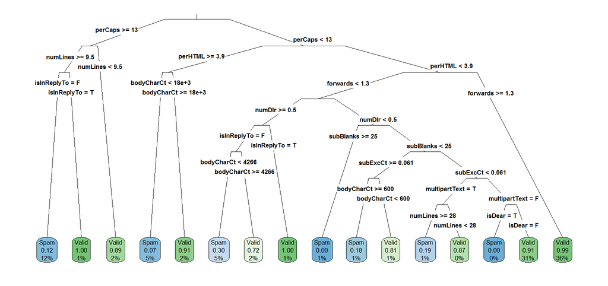

[output not shown]

[output cut: 6 more lines]

[output not shown]

```
##  plotmo grid:    isRe underscore priority isInReplyTo sortedRec subPunc
##                     F          F        F           F         T       F
##  multipartText hasImages isPGPsigned subSpamWords noHost numEnd isYelling
##              F         F           F            F      F      F         F
##  isOrigMsg isDear isWrote numLines bodyCharCt subExcCt subQuesCt numAtt
##          F      F       F       32       1100        0         0      0
##  numRec  perCaps hour perHTML subBlanks forwards avgWordLen numDlr
##       1 6.060606   13       0  13.33333        0   4.455882      0
```

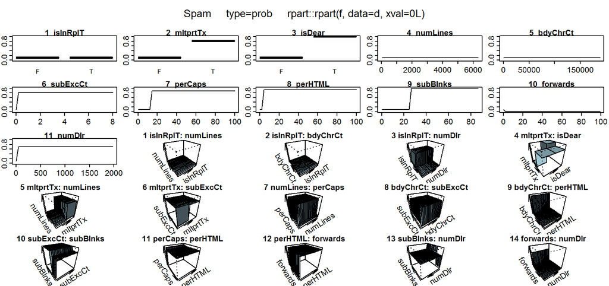

We can see from the decision tree above that we are using “bodyCharCt” multiple times in the splitting process for the training data. Additionally, we can see there is a bit of misclassification particularly as you go down the tree. Particularly in the sense of when we incorrectly classify spam emails as valid.

We will now leverage the test data to produce a confusion matrix to detirmine the model performance in the table below. As mentioned previously, we will be reviewing false positive rate, false negative rate, MMCE (model misclassification error) and ROC AUC.

```
##         predicted
## true     Spam Valid -err.-
##   Spam    403    76     76
##   Valid    77  1313     77
##   -err.-   77    76    153
```

```
##        auc       mmce        fpr        fnr
## 0.95038750 0.08186196 0.05539568 0.15866388
```

#### Hyperparameter Tuning

On each parameter we ran, we performed a cross validation procedure using 10 folds of the training data using AUC as our key performance indicator.

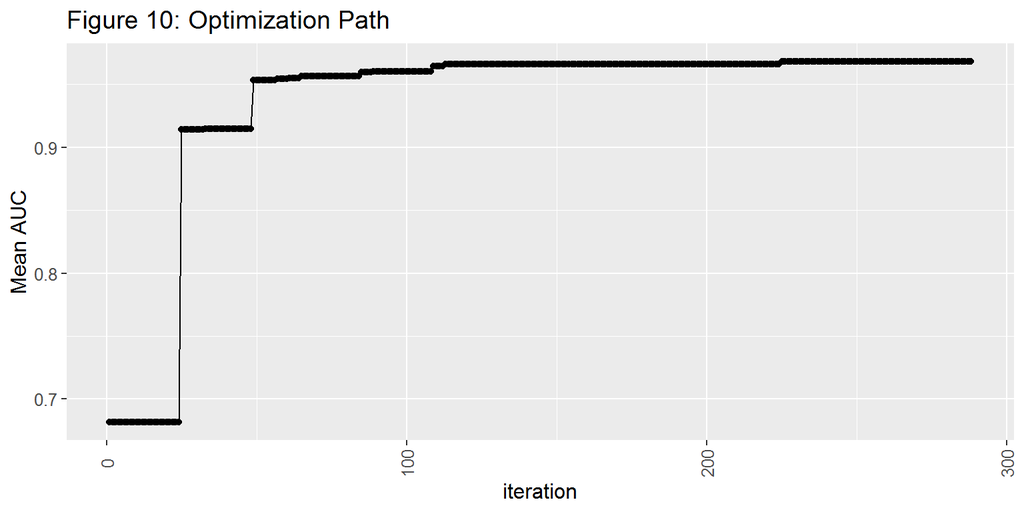

The optimization procedure starts to max out at roughly 0.97 of an AUC using our training data, and our optimized tree is showing to be much larger than our base model. With our plot above, we can see that we are using 50 to 100 total splits in our optimized tree. This is due to the fact that our complexity penalty is lower than our optimized gridsearch threshold at (0.01). This may be causing an overfit to our test set.

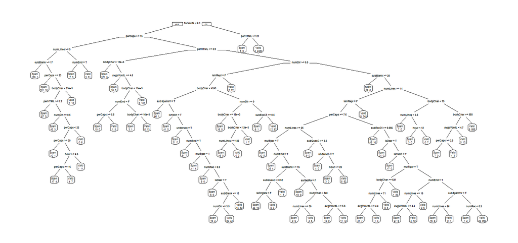

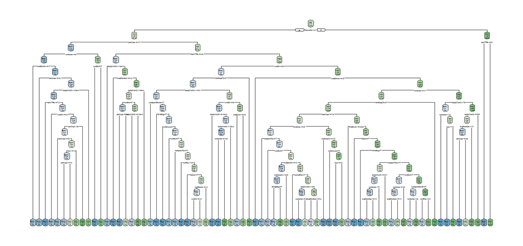

Our resulting model we ran generated a AUC score of greater than 0.96 with a complexity of 0.001. Additionally, the maxdepth for the decision tree nod is always 10 or higher. About half of our models use the information splitting criterion and the majority of the models use a minsplit of 10 or more. Overall, our optimizations lean towards greater splitting and a medium node depth.

We can n see the complexity parameter’s dominance in the figure below. The higher AUC is related to a lower CP (or complexity parameter).

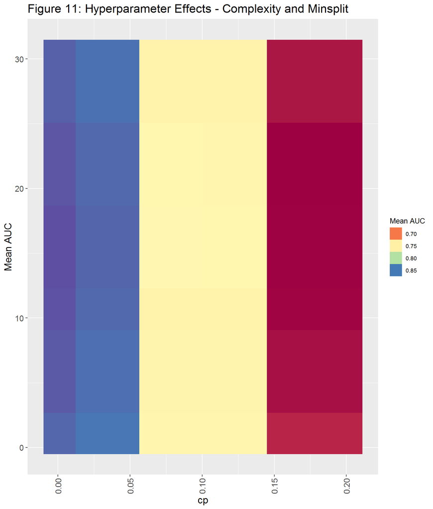

|  | optimized | base |
| --- | --- | --- |
| auc | 0.969 | 0.950 |
| mmce | 0.056 | 0.082 |
| fpr | 0.032 | 0.055 |
| fnr | 0.125 | 0.159 |

# Ensemble Hyper Parameter Tuning

In a parallel package (https://github.com/dhyanshah/MS7333_QTW/blob/master/Case5/Case5-Spam.ipynb) we explored a series of models and estimator tuning procedures to test which model and tuning packages would generate the highest AUC score.

|  | Ensemble_Optimized | optimized | base |
| --- | --- | --- | --- |
| auc | 0.721 | 0.969 | 0.950 |
| mmce | 0.381 | 0.056 | 0.082 |
| fpr | 0.489 | 0.032 | 0.055 |
| fnr | 0.069 | 0.125 | 0.159 |

While our grid searched optimized model exceeded our base model on each metric, we will want to visualize the optimizations using an ROC curve, which you can see below.

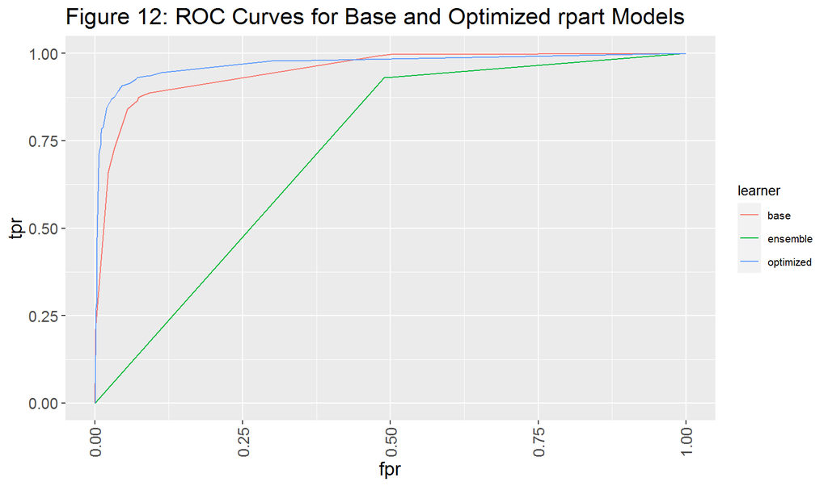

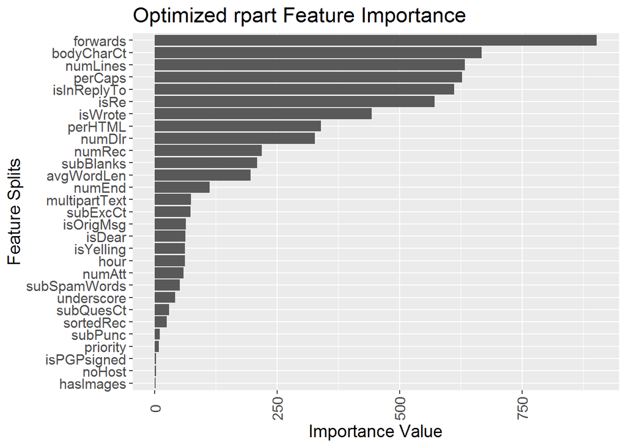

```r
# which variables are most important?
dat <- data.frame(vars=names(splits$variable.importance),
                  importance=splits$variable.importance)
# plot the feature importances
ggplot(dat, aes(reorder(vars, importance, sum), importance))+
    coord_flip()+
    geom_col()+
    theme(legend.position = "bottom",
            legend.text=element_text(size=8),
        legend.title = element_text(size=10),
        axis.text.x = element_text(angle=90, vjust=0.5),
        text=element_text(size=14))+
    ggtitle("Optimized rpart Feature Importance")+
    xlab("Feature Splits")+
    ylab("Importance Value")
```